# Higher Education in 2018-2019

Kelsey Pearson

2023-09-18

To demonstrate some of the essential skills required for this role, candidates are asked to produce a piece of work for presentation at the interview.

Using data freely available via The Higher Education Statistics Agency (HESA) at https://www.hesa.ac.uk/data-and-analysis, for 2018/19 academic year, produce a report showing how the University of Edinburgh compares with the University of Aberdeen, the University of Glasgow, the University of Strathclyde and the University of St Andrews on the following metrics:

- Number of Undergraduate and Postgraduate Taught students
- The ratio of students to staff (‘SSR’)
- Income to University per academic staff member

You should clearly note any assumptions you have made as part of the analysis.

## Number of Undergraduate and Postgraduate Taught students

Data sourced from: https://www.hesa.ac.uk/data-and-analysis/students/table-1

Method:

Filter for the following universities: University of Edinburgh; University of Aberdeen, University of Glasgow; University of Strathclyde; and University of St. Andrews

Filter for following levels of study: All undergraduate; and Postgraduate (taught)

Include all years of study, mode of study, and do not consider other categories such as sex or domicile

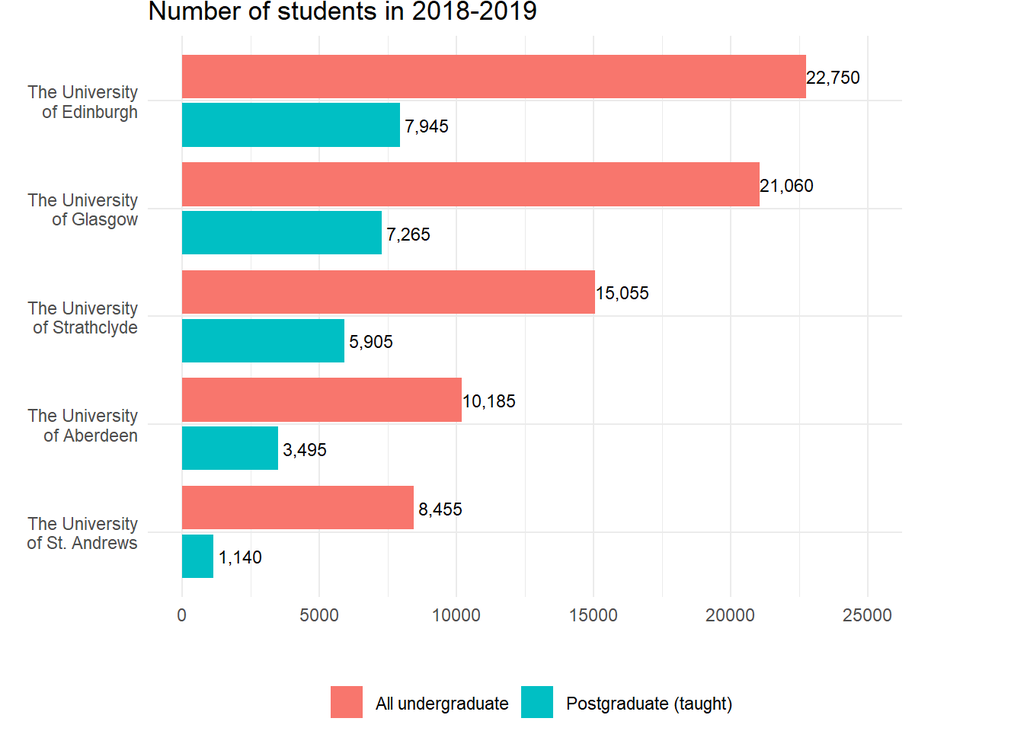

Student population in 2018-2019 (sorted by Total)

| HE Provider | Postgraduate (taught) | Undergraduate | Total |
| --- | --- | --- | --- |
| The University of Edinburgh | 7,945 | 22,750 | 30,695 |
| The University of Glasgow | 7,265 | 21,060 | 28,325 |
| The University of Strathclyde | 5,905 | 15,055 | 20,960 |
| The University of Aberdeen | 3,495 | 10,185 | 13,680 |
| The University of St. Andrews | 1,140 | 8,455 | 9,595 |

The University of Edinburgh has the largest student population with 30,695 students studying at Undergraduate level (22,750) and in Postgraduate Taught coures (7,945).

The University of St. Andrews has the smallest student population with 9,595 students studying in Undergraduate level (8,455) and in Postgraduate Taught courses (1,140).

## Ratio of students to staff (‘SSR’)

Number of students per member of staff. Need to consider FTE, placements

Assumptions and considerations:

Undergraduate and postgraduate taught students in full-time education

Academic staff, full time, non-atypical contract

SSR calculation

Staff levels in 2018-2019

| HE Provider | Total |
| --- | --- |
| The University of Edinburgh | 14410 |
| The University of Glasgow | 8015 |
| The University of Strathclyde | 3850 |
| The University of Aberdeen | 3230 |
| The University of St. Andrews | 2780 |

SSR when considering Undergraduate and Postgraduate taught students and all staff in 2018-2019

| HE Provider | Students | Total Staff | SSR |
| --- | --- | --- | --- |
| The University of Edinburgh | 30695 | 14410 | 2.13 |
| The University of St. Andrews | 9595 | 2780 | 3.45 |
| The University of Glasgow | 28325 | 8015 | 3.53 |
| The University of Aberdeen | 13680 | 3230 | 4.24 |
| The University of Strathclyde | 20960 | 3850 | 5.44 |

| HE Provider | Students | Academic staff | SSR |
| --- | --- | --- | --- |
| The University of Edinburgh | 30695 | 24150 | 1.27 |
| The University of St. Andrews | 9595 | 5250 | 1.83 |
| The University of Glasgow | 28325 | 14925 | 1.90 |
| The University of Aberdeen | 13680 | 5875 | 2.33 |
| The University of Strathclyde | 20960 | 7395 | 2.83 |

## Income to University per academic staff member

The The University of Edinburgh had the largest income in 2018-2019, with an income of £1,101,504.

Income per academic staff member in 2018-2019

| HE Provider | Academic staff | Total income (£) | Income per academic staff member (£) |
| --- | --- | --- | --- |
| The University of St. Andrews | 5,250 | £ 257,448 | £49.04 |
| The University of Glasgow | 14,925 | £ 687,896 | £46.09 |
| The University of Edinburgh | 24,150 | £1,101,504 | £45.61 |
| The University of Strathclyde | 7,395 | £ 336,216 | £45.47 |
| The University of Aberdeen | 5,875 | £ 228,494 | £38.89 |